# 14-15. Probability Laws

## Preparatory work

Read section 3.1, with special attention on the Addition Rule, the General Addition Rule, the Complement Rule, and the Multiplication Rule.

## Combining probabilities

The game “Farkle” involves rolling six dice at once. The player receives 1500 points for a “straight” (every number 1-6 is represented in the result), but also receives 1500 points for “three pair” (for example, rolling 2, 2, 4, 4, 5, 5).  
Their probabilities are P(straight) = 0.015 and P(three pair) = 0.038.

1. What is the probability of getting a straight or three pair?
2. What is the probability of getting a straight and three pair (on the same roll)?
3. What is the probability of getting a straight, then three pair (on the next roll)?
4. What is the probability of not getting a straight?

## Drawing the line

A 52-card deck is shuffled.

1. What is the probability that the top card is 2♡?
2. What is the probability that the second card is 2♣?
3. What is the probability that the top two cards, in order, are 2♡ and 2♣? (Caution: It’s a trap!)

## When to add? When to multiply?

A and B are events. Their probabilities are P(A) and P(B).

P(A)+P(B) calculates __________, provided _________.

P(A)*P(B) calculates __________, provided _________.

1-P(A) calculates ___________.

## When to add? When to multiply?

A and B are events. Their probabilities are P(A) and P(B).

P(A)+P(B) calculates P(A or B), provided A and B are disjoint (mutually exclusive).

P(A)*P(B) calculates P(A and B), provided A and B are independent.

1-P(A) calculates P(not A).

## Sum law (basic)

$$P(A \text{ or } B) = P(A)+P(B)$$

…when A and B are **disjoint** (mutually exclusive), meaning they cannot both happen. If events aren’t disjoint, this rule does not apply.

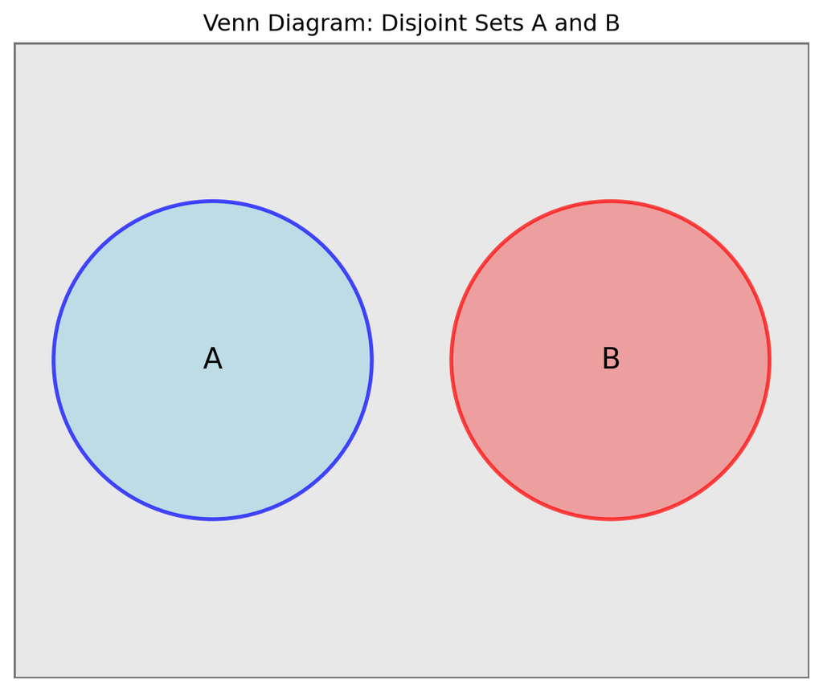

Figure 1: Disjoint sets

## Sum law (full)

If A and B can occur together, then P(A)+P(B) counts P(A and B) twice. If we can calculate that, and we can correct for it:

$$P(A \text{ or } B) = P(A)+P(B) - P(A \text{ and } B)$$

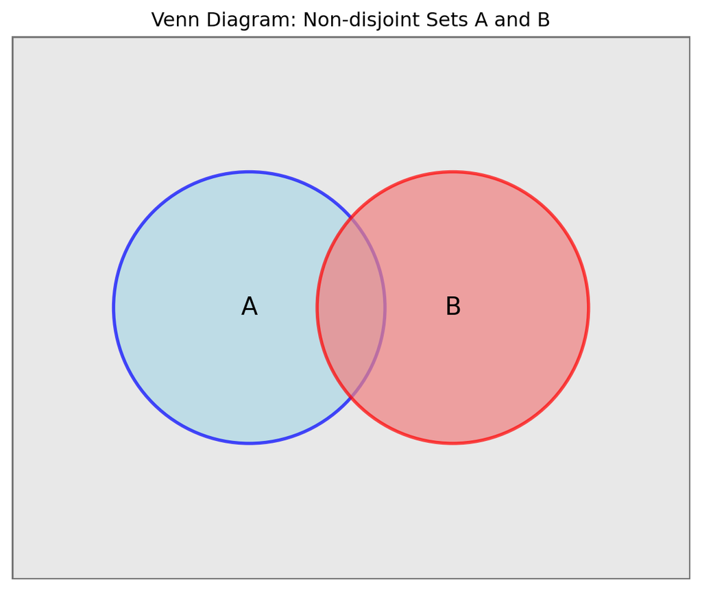

Figure 2: Non-disjoint sets

## Calculate using the laws

P(wearing a red shirt today) = 0.1

P(wearing a purple shirt today) = 0.3

P(having a headache today) = 0.1

1. What is the probability of wearing a red or purple shirt today?
2. What is the probability of wearing a purple shirt and having a headache today?
3. Can you identify any implicit assumptions used in your calculations above?

## Product law (basic)

P(A and B) = P(A)*P(B) when A and B are **independent**, meaning that neither event makes the other more or less likely. (If events are dependent, this law does not apply.)

1. $P(\text{three coins all land heads}) = \frac{1}{2} \cdot \frac{1}{2} \cdot \frac{1}{2}$
2. $P(\text{critical hit, twice}) = 1/20 \cdot 1/20$
3. $P(\text{ card is a red two}) = 1/2 * 1/13$
4. $P(\text{both parents have SCT sickle cell trait}) = 0.006 \cdot 0.006$ (but this calculation is naive and wrong…)

## Solve both and compare

We roll a d6.

1. Calculate P(the result is even)
2. Calculate P(the result is prime)
3. Calculate P(the result is even and prime)

A person is surveyed at random.

P(the person is male) = 0.5

P(the person likes hats) = 0.4

4. Calculate P(the person is male and likes hats)

## Product law (full)

$$P(A \text{ and } B) = P(A)*P(B | A)$$

This law always works, but requires a version of P(B) which recalculated under the assumption that A is true. This is called the **conditional probability of $B$ given $A$** (The topic of the next slide deck)

P(even and prime) = 0.5*P(a given even number is prime)

P(male who likes hats) = 0.5*P(a given male likes hats)

P(both parents have SCT) = 0.006*P(second parent has SCT, assuming first parent does)

## Putting it all together

P(wearing a red shirt today) = 0.1

P(wearing a purple shirt today) = 0.3

P(having a headache today) = 0.1

What is the probability of wearing a purple shirt, or having a headache? Your work should combine two of our probability laws.

## Homework

Solve webwork problems “14-15. Probability Laws”